# 431 Class 24

Thomas E. Love, Ph.D.

2025-12-02

## R packages

```r
knitr::opts_chunk$set(comment = NA)

library(here); library(janitor)
library(broom); library(car)
library(gt); library(GGally)
library(mosaic)       ## for df_stats() function
library(conflicted)   ## introduced today
library(MASS)         ## fitting robust linear models
library(quantreg)     ## fitting quantile regressions
library(easystats)
library(tidyverse)

theme_set(theme_bw())

conflicts_prefer(dplyr::select, base::max, base::mean)
```

## Today’s Agenda

1. The `conflicted` package
2. It’s Just a Linear Model
3. Fitting Robust Linear Models
   - with Huber weights
   - with the biweight
   - Quantile regression

## The conflicted package

https://conflicted.r-lib.org/

- The goal of conflicted is to provide an alternative conflict resolution strategy. R’s default conflict resolution system gives precedence to the most recently loaded package. This can make it hard to detect conflicts, particularly when introduced by an update to an existing package. conflicted takes a different approach, making every conflict an error and forcing you to choose which function to use.

## Conflict Resolution here

In the package setup today, I used the following code to resolve errors that came up in these slides:

**`conflicts_prefer(dplyr::select, base::max, base::mean)`**

- That was the complete set of conflicts I had to resolve to get the slides to run.
- As it turns out, though, there are lots of other conflicts that didn’t crop up in building these slides, because the relevant conflict never emerged…

## What else does conflicted do?

The complete list of 35 conflicts is posted to [our README](https://github.com/THOMASELOVE/431-classes-2025/blob/main/class24/README.md).

```r
conflict_scout()
```

```
35 conflicts
```

```
• `chisq.test()`: janitor and stats
```

```
• `clean_names()`: insight and janitor
```

```
• `cor()`: mosaic and stats
```

```
• `cor_test()`: correlation and mosaic
```

```
• `count()`: mosaic and dplyr
```

```
• `cov()`: mosaic and stats
```

```
• `cross()`: purrr and mosaic
```

```
• `deltaMethod()`: mosaic and car
```

```
• `do()`: mosaic and dplyr
```

```
• `expand()`: tidyr and Matrix
```

```
• `filter()`: dplyr and stats
```

```
• `fisher.test()`: janitor and stats
```

```
• `IQR()`: mosaic and stats
```

```
• `lag()`: dplyr and stats
```

```
• `latex()`: quantreg and gt
```

```
• `logit()`: mosaic and car
```

```
• `max()`: base
```

```
• `mean()`: base
```

```
• `min()`: mosaic and base
```

```
• `pack()`: tidyr and Matrix
```

```
• `prod()`: mosaic and base
```

```
• `prop.test()`: mosaic and stats
```

```
• `range()`: mosaic and base
```

```
• `recode()`: dplyr and car
```

```
• `remove_empty()`: datawizard and janitor
```

```
• `remove_empty_rows()`: datawizard and janitor
```

```
• `rescale()`: datawizard and mosaic
```

```
• `sample()`: mosaic and base
```

```
• `select()`: dplyr
```

```
• `some()`: purrr and car
```

```
• `stat()`: mosaic and ggplot2
```

```
• `sum()`: mosaic and base
```

```
• `tally()`: mosaic and dplyr
```

```
• `unpack()`: tidyr and Matrix
```

```
• `var()`: mosaic and stats
```

# It’s Just a Linear Model

## Common Statistical Tests are Linear Models

Jonas Kristoffer Lindelov has built up a terrific resource to explain this at

https://lindeloev.github.io/tests-as-linear/

What’s the point?

[figure not shown]

## Consider Study 1 from Project B.

- Analysis A. Compare two means/medians using paired samples
  - This is a linear model. See Section 4.2 of [Lindelov](https://lindeloev.github.io/tests-as-linear/)

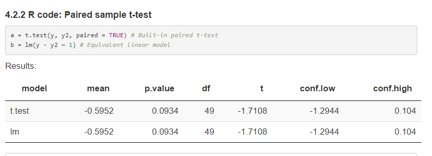

## Project B Study 1?

- Analysis B. Compare two means/medians using independent samples
  - This is a linear model, and not just for the t test. See Section 5 of [Lindelov](https://lindeloev.github.io/tests-as-linear/)
- Analysis C. Compare 3-6 means/medians using independent samples
  - ANOVA is obviously a linear model, but actually we can generate (essentially) the Kruskal-Wallis this way, too. See Section 6.1 of [Lindelov](https://lindeloev.github.io/tests-as-linear/)

## Project B Study 1?

- Analysis D. Create and analyze a 2x2 table
  - Yes, the chi-square test of independence can emerge from a linear model. See Section 7.2 of [Lindelov](https://lindeloev.github.io/tests-as-linear/)
- Analysis E. Create and analyze a JxK table, where $2 \leq J \leq 5$ and $3 \leq K \leq 5$
  - Linear model, as in the 2x2 case. See Section 7.2 of [Lindelov](https://lindeloev.github.io/tests-as-linear/)

Analyses D-E are more commonly thought about in the context of generalized linear models, as we’ll see in 432.

# Robust Linear Models: A Brief Introduction

## The `crimestat` data

For each of 51 states (including the District of Columbia), we have the state’s ID number, postal abbreviation and full name, as well as:

- **crime** - the violent crime rate per 100,000 people
- **poverty** - the official poverty rate (% of people living in poverty in the state/district) in 2014
- **single** - the percentage of households in the state/district led by a female householder with no spouse present and with her own children under 18 years living in the household in 2016

## The `crimestat` data set

```r
crimestat <-
  read_csv(here("c24/data/crimestat.csv"), show_col_types = FALSE) |>
  janitor::clean_names()
crimestat
```

```
# A tibble: 51 × 6
     sid state crime poverty single state_full
   <dbl> <chr> <dbl>   <dbl>  <dbl> <chr>
 1     1 AL     427.    19.2   9.02 Alabama
 2     2 AK     636.    11.4   7.63 Alaska
 3     3 AZ     400.    18.2   8.31 Arizona
 4     4 AR     480.    18.7   9.41 Arkansas
 5     5 CA     396.    16.4   7.25 California
 6     6 CO     309.    12.1   6.75 Colorado
 7     7 CT     237.    10.8   8.04 Connecticut
 8     8 DE     489.    13     6.52 Delaware
 9     9 DC    1244.    18.4   8.41 District of Columbia
10    10 FL     540.    16.6   8.29 Florida
# ℹ 41 more rows
```

## Our objective

Our main goal will be to build a linear regression model to predict **crime** using centered versions of both **poverty** and **single**.

```r
crimestat <- crimestat |>
    mutate(pov_c = poverty - mean(poverty),
           single_c = single - mean(single))
```

We’re centering so that the intercept term is more interpretable.

## Numerical Summaries

```r
df_stats(~ crime + poverty + pov_c + single + single_c, data = crimestat) |>
  gt() |> fmt_number(columns = min:sd, decimals = 2) |>
  tab_options(table.font.size = 24)
```

| response | min | Q1 | median | Q3 | max | mean | sd | n | missing |
| --- | --- | --- | --- | --- | --- | --- | --- | --- | --- |
| crime | 99.30 | 260.20 | 326.50 | 427.35 | 1,244.40 | 364.41 | 179.05 | 51 | 0 |
| poverty | 9.20 | 12.15 | 14.80 | 17.20 | 21.90 | 14.87 | 3.08 | 51 | 0 |
| pov_c | −5.67 | −2.72 | −0.07 | 2.33 | 7.03 | 0.00 | 3.08 | 51 | 0 |
| single | 4.48 | 6.75 | 7.63 | 8.50 | 11.59 | 7.69 | 1.61 | 51 | 0 |
| single_c | −3.21 | −0.94 | −0.06 | 0.82 | 3.90 | 0.00 | 1.61 | 51 | 0 |

## Transform Outcome?

```r
boxCox(lm(crime ~ pov_c + single_c, data = crimestat))
```

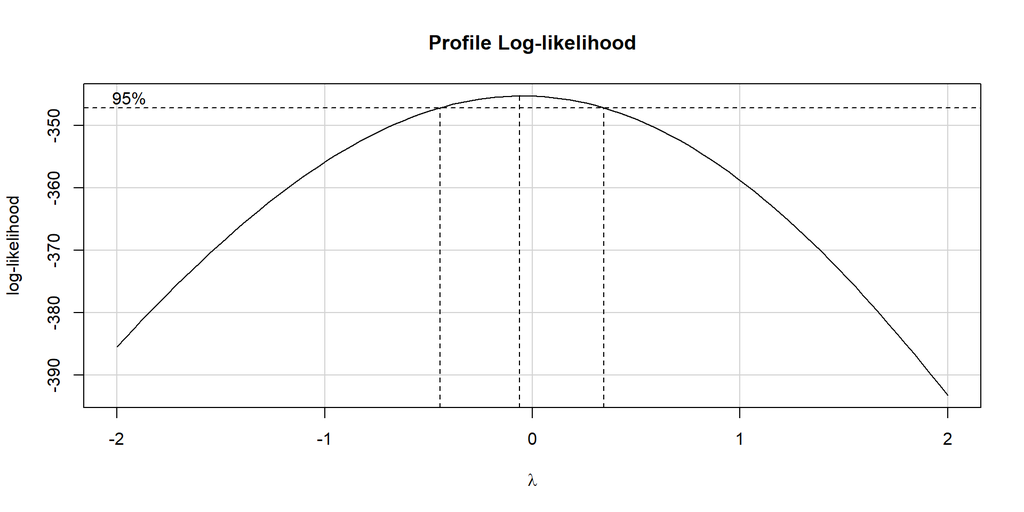

## Scatterplot Matrix

```r
temp <- crimestat |>
  mutate(logcrime = log(crime)) |>
  select(pov_c, single_c, logcrime)

ggpairs(temp,
        title = "Scatterplot Matrix for crimestat",
        lower = list(combo = wrap("facethist"), bins = 7))
```

## Scatterplot Matrix

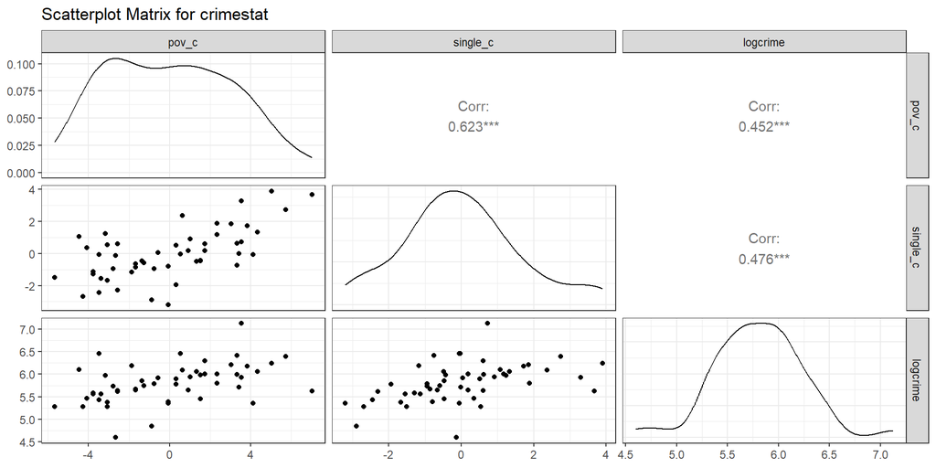

## OLS linear model

```r
crimestat <- crimestat |> mutate(logcrime = log(crime))
fit_ols <- lm(logcrime ~ pov_c + single_c, data = crimestat)
```

Note what happens when we put the model in parentheses…

```r
(fit_ols <- lm(logcrime ~ pov_c + single_c, data = crimestat))
```

```
Call:
lm(formula = logcrime ~ pov_c + single_c, data = crimestat)

Coefficients:
(Intercept)        pov_c     single_c
    5.80363      0.03581      0.08543
```

## Coefficients of `fit_ols`

```r
model_parameters(fit_ols, ci = 0.95,
                 pretty_names = FALSE, include_info = TRUE)
```

```
Parameter   | Coefficient |   SE |        95% CI |  t(48) |      p
------------------------------------------------------------------
(Intercept) |        5.80 | 0.05 | [ 5.70, 5.91] | 109.28 | < .001
pov_c       |        0.04 | 0.02 | [-0.01, 0.08] |   1.61 | 0.114
single_c    |        0.09 | 0.04 | [ 0.00, 0.17] |   2.01 | 0.050

Model: logcrime ~ pov_c + single_c (51 Observations)
Sigma: 0.379 (df = 48)
RMSE : 0.368
R2: 0.266; adjusted R2: 0.235
```

What do the 95% confidence interval estimates suggest about `pov_c` and `single_c`?

## Exponentiated Coefficients

```r
model_parameters(fit_ols, exponentiate = TRUE, ci = 0.95,
                 pretty_names = FALSE, include_info = TRUE)
```

```
Parameter   | Coefficient |    SE |           95% CI |  t(48) |      p
----------------------------------------------------------------------
(Intercept) |      331.50 | 17.61 | [297.93, 368.86] | 109.28 | < .001
pov_c       |        1.04 |  0.02 | [  0.99,   1.08] |   1.61 | 0.114
single_c    |        1.09 |  0.05 | [  1.00,   1.19] |   2.01 | 0.050

Model: logcrime ~ pov_c + single_c (51 Observations)
Sigma: 0.379 (df = 48)
RMSE : 0.368
R2: 0.266; adjusted R2: 0.235
```

## Performance of `fit_ols`

```r
model_performance(fit_ols)
```

```
# Indices of model performance

AIC  | AICc |  BIC |    R2 | R2 (adj.) |  RMSE | Sigma
------------------------------------------------------
50.8 | 51.6 | 58.5 | 0.266 |     0.235 | 0.368 | 0.379
```

## OLS Checking (1/3)

```r
check_model(fit_ols, check = c("linearity", "homogeneity"))
```

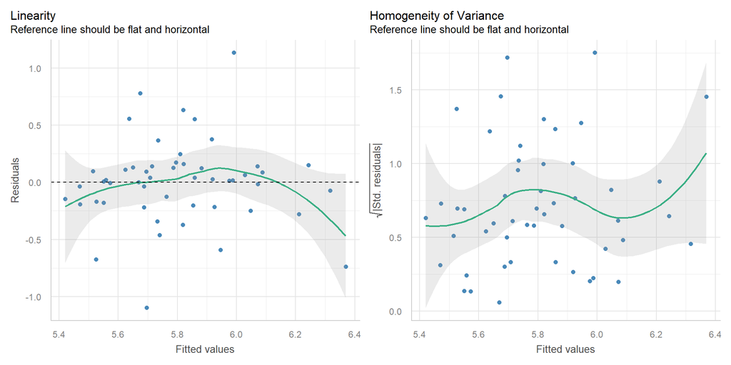

## OLS Checking (2/3)

```r
check_model(fit_ols, check = c("pp_check", "outliers"))
```

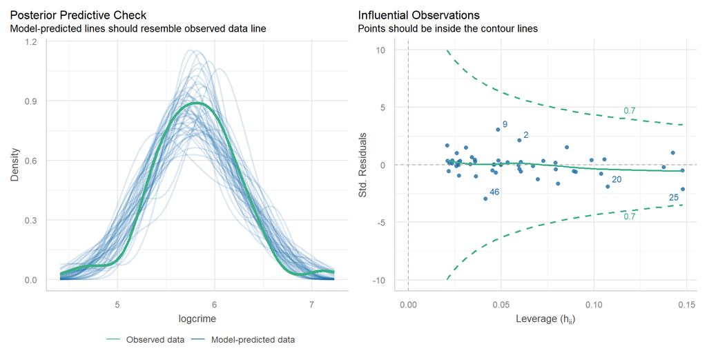

## OLS Checking (3/3)

```r
check_model(fit_ols, detrend = FALSE, check = c("normality", "qq"))
```

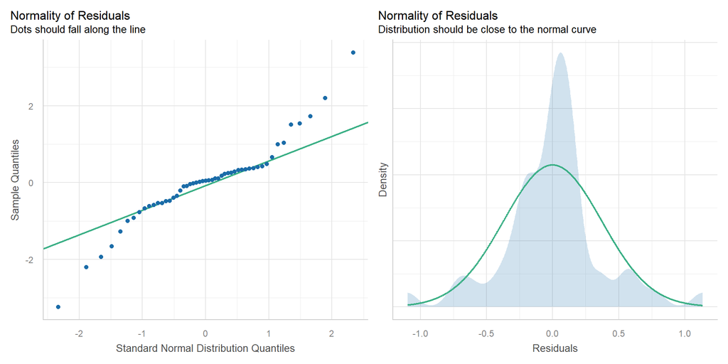

## Which points are of special interest?

Largest residuals in absolute value?

```r
aug_ols <- augment(fit_ols)
aug_ols <- aug_ols |> mutate(state = crimestat$state, sid = crimestat$sid,
                       abs_res = abs(.resid))
aug_ols |> select(sid, state, logcrime, pov_c, single_c, .resid, abs_res,
               everything()) |>
  arrange(desc(abs_res)) |> head()
```

```
# A tibble: 6 × 12
    sid state logcrime  pov_c single_c .resid abs_res .fitted   .hat .sigma
  <dbl> <chr>    <dbl>  <dbl>    <dbl>  <dbl>   <dbl>   <dbl>  <dbl>  <dbl>
1     9 DC        7.13  3.53    0.721   1.13    1.13     5.99 0.0482  0.344
2    46 VT        4.60 -2.67   -0.139  -1.10    1.10     5.70 0.0414  0.347
3     2 AK        6.45 -3.47   -0.0588  0.781   0.781    5.67 0.0595  0.365
4    25 MS        5.63  7.03    3.67   -0.739   0.739    6.37 0.148   0.365
5    20 ME        4.85 -0.873  -2.90   -0.674   0.674    5.52 0.107   0.369
6    29 NV        6.45  0.527  -0.0288  0.635   0.635    5.82 0.0207  0.372
# ℹ 2 more variables: .cooksd <dbl>, .std.resid <dbl>
```

## Collinearity in `fit_ols`?

```r
check_collinearity(fit_ols)
```

```
# Check for Multicollinearity

Low Correlation

     Term  VIF   VIF 95% CI adj. VIF Tolerance Tolerance 95% CI
    pov_c 1.63 [1.26, 2.53]     1.28      0.61     [0.40, 0.79]
 single_c 1.63 [1.26, 2.53]     1.28      0.61     [0.40, 0.79]
```

## Prediction for new data

- Declare outcome transformation in model.

```r
fit_ols2 <- lm(log(crime) ~ pov_c + single_c, data = crimestat)
```

- “New” states: `pov_c` = 1, `single_c` = 2.
- What does `fit_ols` predict for log(`crime`)?

```r
estimate_expectation(fit_ols2, ci = 0.95,
                     data = tibble(pov_c = 1, single_c = 2))
```

```
Model-based Predictions

pov_c | single_c | Predicted |   SE |       95% CI
--------------------------------------------------
1     |        2 |      6.01 | 0.09 | [5.83, 6.19]

Variable predicted: crime
Predictions are on the log-scale (consider `transform=TRUE`).
```

## Prediction for new data

Again, we assume we have multiple new states with `pov_c` = 1 and `single_c` = 2.

- What does `fit_ols` predict for average **crime**?

```r
estimate_expectation(fit_ols2, ci = 0.95, transform = TRUE,
                     data = tibble(pov_c = 1, single_c = 2))
```

```
Model-based Predictions

pov_c | single_c | Predicted |           95% CI
-----------------------------------------------
1     |        2 |    407.60 | [339.74, 489.03]

Variable predicted: crime
```

# Robust Linear Model with Huber weights

## Robust Linear Models

There are several ways to do robust linear regression using M-estimation, including weighting using Huber and bisquare strategies.

- Robust linear regression here will make use of a method called iteratively re-weighted least squares (IRLS) to estimate models.
- M-estimation defines a weight function which is applied during estimation.

## Using Huber weights

- The weights depend on the residuals and the residuals depend on the weights, so an iterative process is required.

We’ll fit the model, using the default weighting choice: what are called Huber weights, where observations with small residuals get a weight of 1, and the larger the residual, the smaller the weight.

## New model (using `MASS::rlm`)

```r
rob_huber <- rlm(logcrime ~ pov_c + single_c, data = crimestat)

model_parameters(rob_huber, ci = 0.95, pretty_names = F, include_info = T)
```

```
Parameter   | Coefficient |   SE |        95% CI |  t(48) |      p
------------------------------------------------------------------
(Intercept) |        5.80 | 0.04 | [ 5.72, 5.88] | 147.26 | < .001
pov_c       |        0.03 | 0.02 | [ 0.00, 0.07] |   1.99 | 0.052
single_c    |        0.09 | 0.03 | [ 0.03, 0.15] |   2.89 | 0.006

Model: logcrime ~ pov_c + single_c (51 Observations)
Sigma: 0.379 (df = 48)
RMSE : 0.368
```

Is this a very different result than ordinary least squares gave us?

## Glance: `rob_huber` and OLS

```r
glance(rob_huber) |> gt() |> fmt_number(decimals = 2) |>
  tab_options(table.font.size = 24)
```

| sigma | converged | logLik | AIC | BIC | deviance | nobs |
| --- | --- | --- | --- | --- | --- | --- |
| 0.22 | TRUE | −21.39 | 50.78 | 58.51 | 6.91 | 51.00 |

```r
glance(fit_ols) |>
  select(sigma, logLik, AIC, BIC, deviance, nobs,
         r.squared, adj.r.squared) |>
  gt() |> fmt_number(decimals = 2) |>
  tab_options(table.font.size = 24)
```

| sigma | logLik | AIC | BIC | deviance | nobs | r.squared | adj.r.squared |
| --- | --- | --- | --- | --- | --- | --- | --- |
| 0.38 | −21.38 | 50.75 | 58.48 | 6.90 | 51.00 | 0.27 | 0.24 |

## Understanding the Huber weights

Let’s augment the data with results from this model, including the weights.

```r
crime_with_huber <- augment(rob_huber, crimestat) |>
    mutate(w = rob_huber$w) |> arrange(w)

crime_with_huber |>
  select(sid, state, w, logcrime, crime, pov_c, single_c,
         .fitted, .resid, everything()) |>
  head(4)
```

```
# A tibble: 4 × 16
    sid state     w logcrime  crime pov_c single_c .fitted .resid poverty single
  <dbl> <chr> <dbl>    <dbl>  <dbl> <dbl>    <dbl>   <dbl>  <dbl>   <dbl>  <dbl>
1     9 DC    0.257     7.13 1244.   3.53   0.721     5.98  1.14     18.4   8.41
2    46 VT    0.267     4.60   99.3 -2.67  -0.139     5.70 -1.10     12.2   7.55
3     2 AK    0.379     6.45  636.  -3.47  -0.0588    5.68  0.775    11.4   7.63
4    25 MS    0.399     5.63  278.   7.03   3.67      6.37 -0.737    21.9  11.4
# ℹ 5 more variables: state_full <chr>, .hat <dbl>, .sigma <dbl>,
#   .cooksd <dbl>, .std.resid <dbl>
```

## Huber Weights

```r
crime_with_huber |> select(state, w, .resid) |>
  arrange(desc(abs(.resid))) |> head(4)
```

```
# A tibble: 4 × 3
  state     w .resid
  <chr> <dbl>  <dbl>
1 DC    0.257  1.14
2 VT    0.267 -1.10
3 AK    0.379  0.775
4 MS    0.399 -0.737
```

```r
crime_with_huber |> select(state, w, .resid) |>
  arrange(desc(abs(.resid))) |> slice(14,15,50,51)
```

```
# A tibble: 4 × 3
  state     w   .resid
  <chr> <dbl>    <dbl>
1 RI    0.877 -0.335
2 GA    1     -0.283
3 AL    1     -0.00622
4 WI    1      0.00530
```

## What is the pattern?

```r
ggplot(crime_with_huber, aes(x = abs(.resid), y = w)) +
    geom_label(aes(label = state))
```

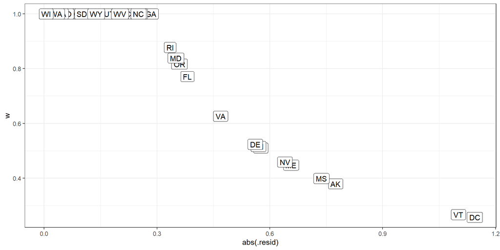

## Conclusions: Weights Plot

- District of Columbia will be down-weighted the most, followed by Vermont, then Alaska and Mississippi.
- But many of the observations will have a weight of 1.
- In ordinary least squares, all observations would have weight 1.
- So the more cases in the robust regression that have a weight close to one, the closer the results of the OLS and robust procedures will be.

# Robust linear model using the biweight

## Using the biweight

The **biweight**, or bisquare or Tukey’s bisquare is another weighing approach, in which all cases with a non-zero residual get down-weighted at least a little.

```r
(rob_bw <- rlm(logcrime ~ pov_c + single_c,
                    data = crimestat, psi = psi.bisquare))
```

```
Call:
rlm(formula = logcrime ~ pov_c + single_c, data = crimestat,
    psi = psi.bisquare)
Converged in 18 iterations

Coefficients:
(Intercept)       pov_c    single_c
 5.79991656  0.02651131  0.09960112

Degrees of freedom: 51 total; 48 residual
Scale estimate: 0.23
```

## Robust Model Coefficients

**Huber weights**

```r
model_parameters(rob_huber, ci = 0.95, pretty_names = F)
```

```
Parameter   | Coefficient |   SE |        95% CI |  t(48) |      p
------------------------------------------------------------------
(Intercept) |        5.80 | 0.04 | [ 5.72, 5.88] | 147.26 | < .001
pov_c       |        0.03 | 0.02 | [ 0.00, 0.07] |   1.99 | 0.052
single_c    |        0.09 | 0.03 | [ 0.03, 0.15] |   2.89 | 0.006
```

**Bisquare weights**

```r
model_parameters(rob_bw, ci = 0.95, pretty_names = F)
```

```
Parameter   | Coefficient |   SE |        95% CI |  t(48) |      p
------------------------------------------------------------------
(Intercept) |        5.80 | 0.04 | [ 5.72, 5.88] | 139.15 | < .001
pov_c       |        0.03 | 0.02 | [-0.01, 0.06] |   1.52 | 0.136
single_c    |        0.10 | 0.03 | [ 0.03, 0.17] |   2.98 | 0.005
```

## Robust model performance

**Huber weights**

```r
model_performance(rob_huber); n_obs(rob_huber)
```

```
# Indices of model performance

AIC  | AICc |  BIC |  RMSE | Sigma
----------------------------------
50.8 | 51.7 | 58.5 | 0.368 | 0.379
```

```
[1] 51
```

**Bisquare weights**

```r
model_performance(rob_bw); n_obs(rob_bw)
```

```
# Indices of model performance

AIC  | AICc |  BIC |  RMSE | Sigma
----------------------------------
51.0 | 51.8 | 58.7 | 0.369 | 0.380
```

```
[1] 51
```

## `augment()` for `rob_bw`

```r
crime_bw <- augment(rob_bw, newdata = crimestat) |>
  mutate(w = rob_bw$w) |>
  relocate(c(w, .resid), .before = crime) |>
  arrange(w)

head(crime_bw, 3) |> gt() # smallest three weights
```

| sid | state | w | .resid | crime | poverty | single | state_full | pov_c | single_c | logcrime | .fitted |
| --- | --- | --- | --- | --- | --- | --- | --- | --- | --- | --- | --- |
| 9 | DC | 0.0000000 | 1.1611449 | 1244.4 | 18.4 | 8.41 | District of Columbia | 3.527451 | 0.72117647 | 7.126409 | 5.965264 |
| 46 | VT | 0.0000000 | -1.1170912 | 99.3 | 12.2 | 7.55 | Vermont | -2.672549 | -0.13882353 | 4.598146 | 5.715237 |
| 2 | AK | 0.2632385 | 0.7528882 | 635.8 | 11.4 | 7.63 | Alaska | -3.472549 | -0.05882353 | 6.454884 | 5.701996 |

```r
tail(crime_bw, 3) |> gt() # largest three weights
```

| sid | state | w | .resid | crime | poverty | single | state_full | pov_c | single_c | logcrime | .fitted |
| --- | --- | --- | --- | --- | --- | --- | --- | --- | --- | --- | --- |
| 35 | ND | 0.9998727 | 0.008574042 | 265.1 | 11.1 | 6.40 | North Dakota | -3.772549 | -1.2888235 | 5.580107 | 5.571533 |
| 50 | WI | 0.9999939 | 0.001875577 | 290.3 | 13.2 | 6.82 | Wisconsin | -1.672549 | -0.8688235 | 5.670915 | 5.669039 |
| 12 | HI | 0.9999967 | 0.001358660 | 259.2 | 11.5 | 6.14 | Hawaii | -3.372549 | -1.5488235 | 5.557600 | 5.556241 |

## `rob_bw`: Weights vs. Residuals

```r
ggplot(crime_bw, aes(x = abs(.resid), y = w)) +
    geom_label(aes(label = state))
```

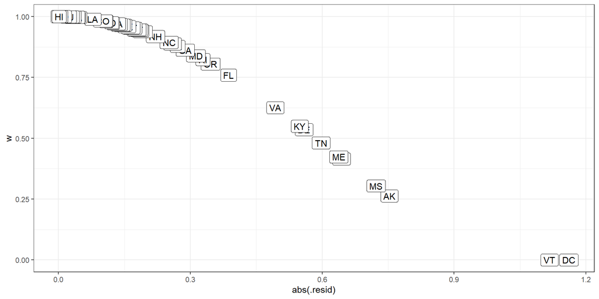

## Conclusions from the biweights plot

Again, cases with large residuals (in absolute value) are down-weighted generally, but here, Vermont and Washington DC receive **no** weight in fitting the final model.

- We can see that the weight given to DC and Vermont is dramatically lower (in fact it is zero) using the bisquare and the parameter estimates from these two different weighting methods differ.
- The maximum weight (here, for Hawaii) for any state using the biweight is still slightly smaller than 1.

# Quantile Regression

## Quantile Regression on the Median

We can use the `rq` function in the `quantreg` package to model the **median** of our outcome (violent crime rate) on the basis of our predictors, rather than the mean, as is the case in ordinary least squares.

```r
(fit_q50 <- rq(logcrime ~ pov_c + single_c, data = crimestat))
```

```
Call:
rq(formula = logcrime ~ pov_c + single_c, data = crimestat)

Coefficients:
(Intercept)       pov_c    single_c
 5.81810182  0.03184378  0.10810788

Degrees of freedom: 51 total; 48 residual
```

## Coefficients in `fit_q50`

```r
model_parameters(fit_q50, ci = 0.95, pretty_names = FALSE)
```

```
# Fixed Effects

Parameter   | Coefficient |   SE |        95% CI |  t(48) |      p
------------------------------------------------------------------
(Intercept) |        5.82 | 0.05 | [ 5.73, 5.91] | 126.04 | < .001
pov_c       |        0.03 | 0.02 | [-0.01, 0.07] |   1.69 | 0.097
single_c    |        0.11 | 0.04 | [ 0.04, 0.18] |   2.99 | 0.004
```

```r
glance(fit_q50) |> gt() |> tab_options(table.font.size = 24)
```

| tau | logLik | AIC | BIC | df.residual |
| --- | --- | --- | --- | --- |
| 0.5 | -15.48026 | 36.96052 | 42.75599 | 48 |

## Estimating a different quantile

Estimate any quantile by specifying the `tau` ($\tau$) parameter.

- Default is `tau` = 0.5, which estimates the median.
- What about estimating, say, the 70th percentile?

```r
(fit_quan70 <- rq(logcrime ~ pov_c + single_c, tau = 0.70,
                  data = crimestat))
```

```
Call:
rq(formula = logcrime ~ pov_c + single_c, tau = 0.7, data = crimestat)

Coefficients:
(Intercept)       pov_c    single_c
 5.92425331  0.03722661  0.09306954

Degrees of freedom: 51 total; 48 residual
```

# Comparing our 4 models

## Comparing coefficients

```r
compare_models(fit_ols, rob_huber, rob_bw, fit_q50,
               ci = 0.95)
```

```
Parameter    |            fit_ols |         rob_huber |             rob_bw |            fit_q50
-----------------------------------------------------------------------------------------------
(Intercept)  | 5.80 ( 5.70, 5.91) | 5.80 (5.72, 5.88) | 5.80 ( 5.72, 5.88) | 5.82 ( 5.73, 5.91)
pov c        | 0.04 (-0.01, 0.08) | 0.03 (0.00, 0.07) | 0.03 (-0.01, 0.06) | 0.03 (-0.01, 0.07)
single c     | 0.09 ( 0.00, 0.17) | 0.09 (0.03, 0.15) | 0.10 ( 0.03, 0.17) | 0.11 ( 0.04, 0.18)
-----------------------------------------------------------------------------------------------
Observations |                 51 |                51 |                 51 |                 51
```

Can we plot these results?

## Comparing coefficients

```r
plot(compare_models(fit_ols, rob_huber, rob_bw, fit_q50,
               ci = 0.95))
```

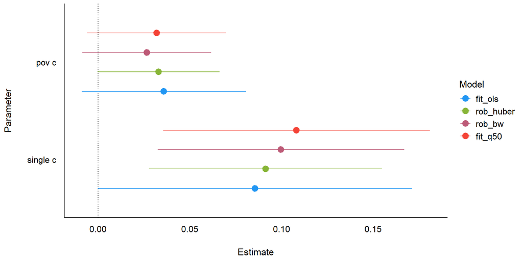

## Exponentiated coefficients

```r
plot(compare_models(fit_ols, rob_huber, rob_bw, fit_q50,
               ci = 0.95, exponentiate = TRUE)) +
  xlim(0.90, 1.25) + geom_vline(xintercept = 1, lty = "dashed")
```

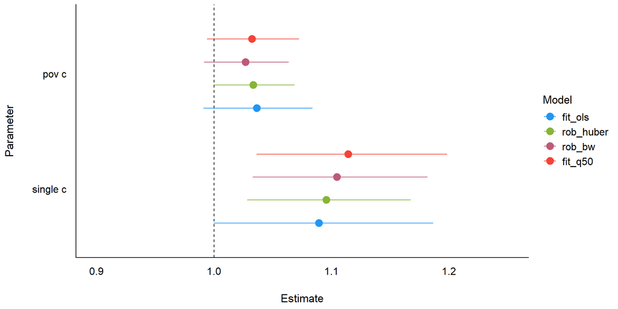

## Comparing performance

```r
compare_performance(fit_ols, rob_huber, rob_bw, fit_q50)
```

```
# Comparison of Model Performance Indices

Name      | Model | AIC (weights) | BIC (weights) |  RMSE | Sigma |    R2
-------------------------------------------------------------------------
fit_ols   |    lm |  50.8 (0.001) |  58.5 (<.001) | 0.368 | 0.379 | 0.266
rob_huber |   rlm |  50.8 (<.001) |  58.5 (<.001) | 0.368 | 0.379 |
rob_bw    |   rlm |  51.0 (<.001) |  58.7 (<.001) | 0.369 | 0.380 |
fit_q50   |    rq |  37.0 (0.997) |  42.8 (0.999) | 0.369 | 0.381 | 0.260

Name      | AICc (weights) | R2 (adj.)
--------------------------------------
fit_ols   |   51.6 (>.999) |     0.235
rob_huber |   51.7 (>.999) |
rob_bw    |   51.8 (>.999) |
fit_q50   |        (>.999) |
```

## Comparing performance

```r
plot(compare_performance(fit_ols, rob_huber, rob_bw, fit_q50))
```

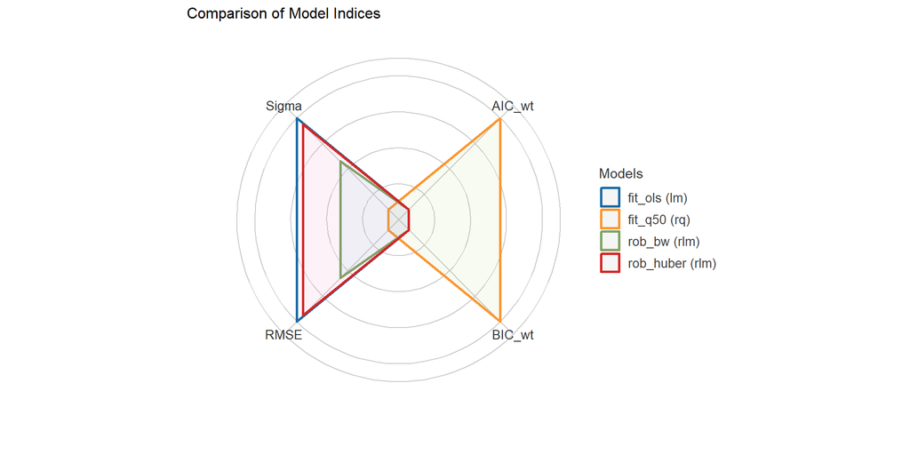

## Prediction in new data

1. Declare outcome transformation in each model.

```r
rob_huber2 <- rlm(log(crime) ~ pov_c + single_c, data = crimestat)
rob_bw2 <- rlm(log(crime) ~ pov_c + single_c,
               data = crimestat, psi = psi.bisquare)
fit_q50 <- rq(log(crime) ~ pov_c + single_c, data = crimestat)
```

2. “New” states: all have `pov_c` = 1 and `single_c` = 2.

```r
new_dat <- tibble(pov_c = 1, single_c = 2)
```

## Predictions: Huber weights

```r
estimate_expectation(rob_huber2, ci = 0.95, data = new_dat)
```

```
Model-based Predictions

pov_c | single_c | Predicted |   SE |       95% CI
--------------------------------------------------
1     |        2 |      6.02 | 0.07 | [5.88, 6.15]

Variable predicted: crime
Predictions are on the log-scale (consider `transform=TRUE`).
```

```r
estimate_expectation(rob_huber2, ci = 0.95, transform = TRUE, data = new_dat)
```

```
Model-based Predictions

pov_c | single_c | Predicted |           95% CI
-----------------------------------------------
1     |        2 |    409.68 | [357.92, 468.92]

Variable predicted: crime
```

## Predictions: Bisquare weights

```r
estimate_expectation(rob_bw2, ci = 0.95, data = new_dat)
```

```
Model-based Predictions

pov_c | single_c | Predicted |   SE |       95% CI
--------------------------------------------------
1     |        2 |      6.03 | 0.07 | [5.88, 6.17]

Variable predicted: crime
Predictions are on the log-scale (consider `transform=TRUE`).
```

```r
estimate_expectation(rob_bw2, ci = 0.95, transform = TRUE, data = new_dat)
```

```
Model-based Predictions

pov_c | single_c | Predicted |           95% CI
-----------------------------------------------
1     |        2 |    413.90 | [358.78, 477.50]

Variable predicted: crime
```

## Quantile (median) regression

```r
estimate_expectation(fit_q50, ci = 0.95, data = new_dat)
```

```
Model-based Predictions

pov_c | single_c | Predicted |   SE |       95% CI
--------------------------------------------------
1     |        2 |      6.07 | 0.08 | [5.90, 6.24]

Variable predicted: crime
Predictions are on the log-scale (consider `transform=TRUE`).
```

```r
estimate_expectation(fit_q50, ci = 0.95, transform = TRUE, data = new_dat)
```

```
Model-based Predictions

pov_c | single_c | Predicted |           95% CI
-----------------------------------------------
1     |        2 |    431.02 | [364.02, 510.35]

Variable predicted: crime
```

## Wrapping Up

1. When comparing the results of a regular OLS regression and a robust regression for a data set which displays outliers, if the results are very different, you will most likely want to use the results from the robust regression.
   - Large differences suggest that the model parameters are being highly influenced by outliers.

## Wrapping Up

2. Different weighting functions have advantages and drawbacks.
   - Huber weights can have difficulties with really severe outliers.
   - Bisquare weights can have difficulties converging or may yield multiple solutions.
   - Quantile regression approaches have some nice properties, but describe medians (or other quantiles) rather than means.